# GEA_Founders_Analysis

Alvaro Regano

27/07/2023

# 1 GEA Founders Analysis

# 2 Objective

Take a look at the new GEA line and conclude that it is an improvement on the last by checking for higher expression of iFlpscLineage BCs in the new founder as well as a higher number of cells expressing the transgene

# 3 Analysis

The dataset conditions is as follows

```
##   Founder Recomb Promoter Origin CMO
## 1   GEA12   FULL    Super   GEA3 301
## 2   GEA12   NONE    Super   GEA3 302
## 3   GEA18   FULL      R26   GEA3 303
## 4    GEA3   NONE      R26   GEA3 304
## 5   GEA27   NONE      R26   GEA2 305
```

```
##
## GEA12_FULL_recomb_iFlpscL   GEA12_NO_recomb_iFlpscL GEA18_FULL_recomb_iFlpscL    GEA3_NO_recomb_iFlpscL   GEA27_NO_recomb_iFlpscL
##                       802                       912                       556                       552                       534
```

## 3.1 Module Scores of the iFlpscLineage cassette

First We will look at the Barcodes grouped to see how the expression rates change

Violin Plots show that GEA12 with Full recombination has a remarkable level of expression of all iFlpscLineage Arrays

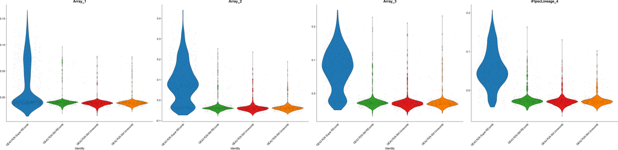

We can also look at the % of cells expressing iFlpscLineage in the dataset

## 3.2 Looking at Expression rates of iFlpscLinage per cell

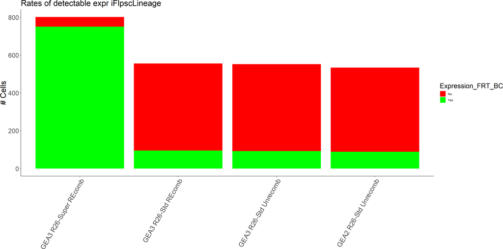

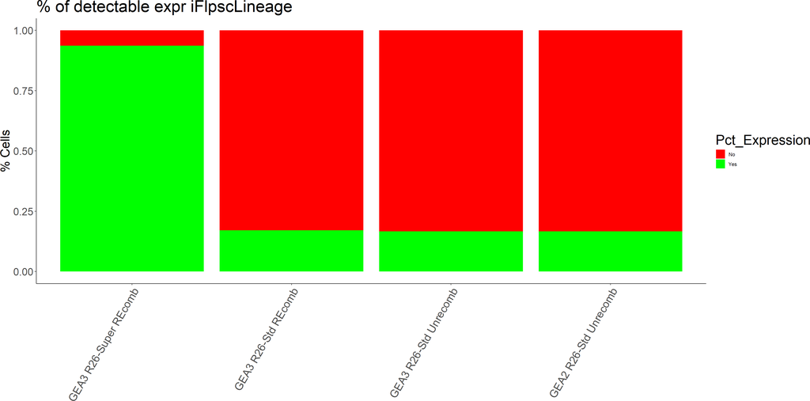

Now in terms of % of counts in the dataset

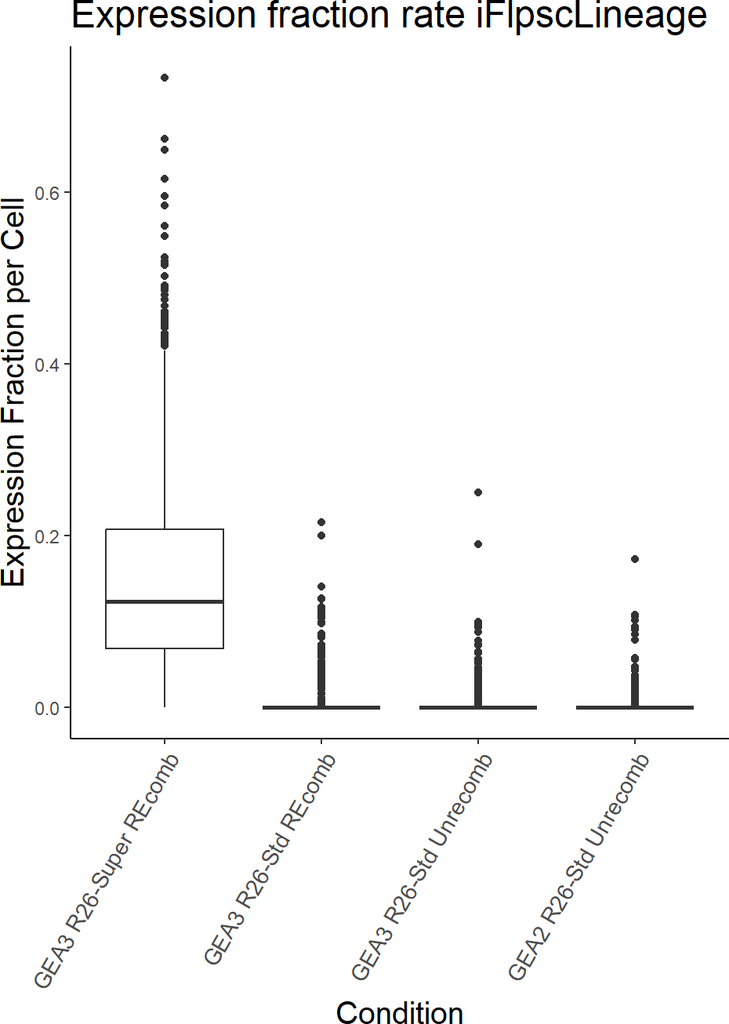

Surprisingly there are some cells in the GEA12_FULL_recomb that seem to have a huge rate of expression of FRT_BCs (over 60%)

We can take a look at rates of expression among arrays

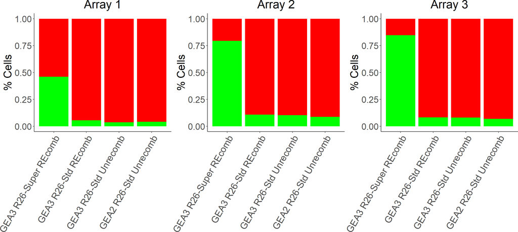

Let’s check the number and percentage of cells expressing more than one Array in the dataset

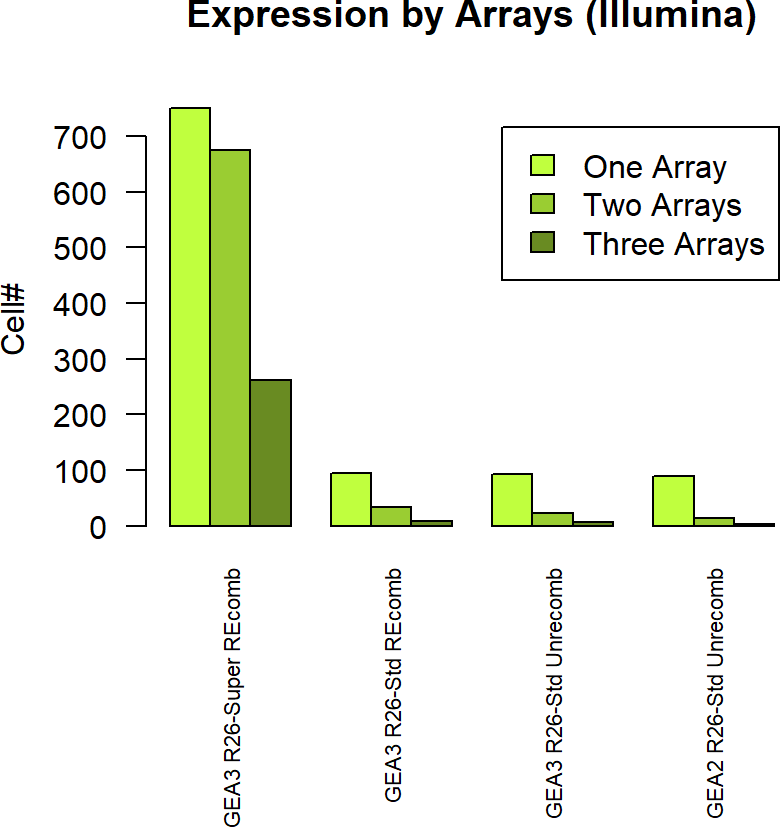

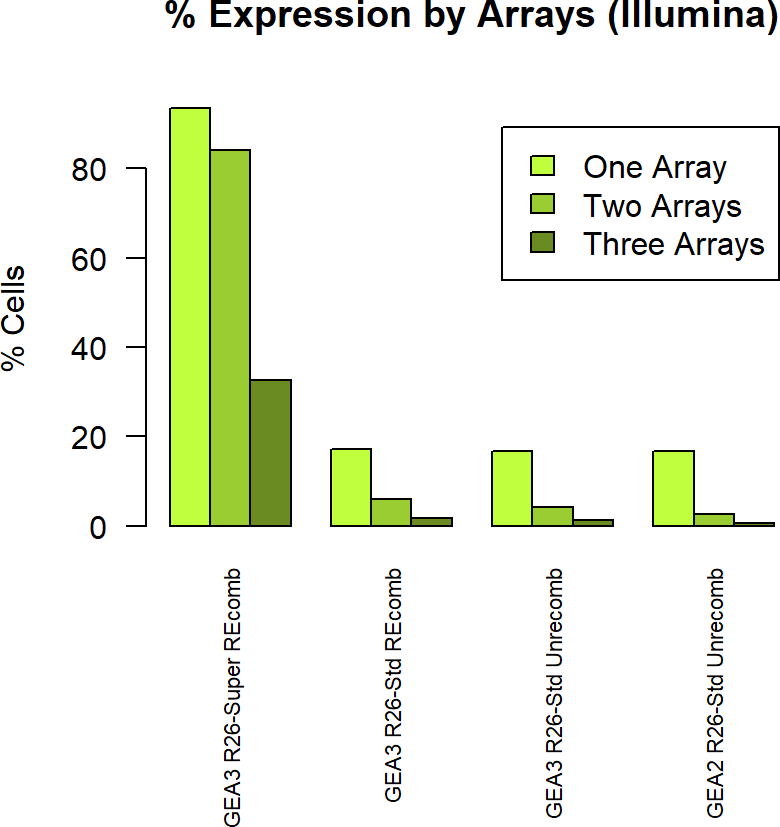

For the GEA12 Founder the proportion of cells expressing iFlpscLineage Barcodes is huge, over 80% of them express at least one iFlpscLineage Array.

## 3.3 Looking at the Distribution of FRT-BCs throughout the populations

### 3.3.1 Looking at FRT-BC Mean Counts per cell

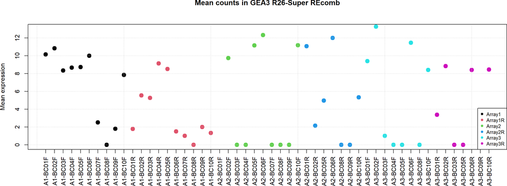

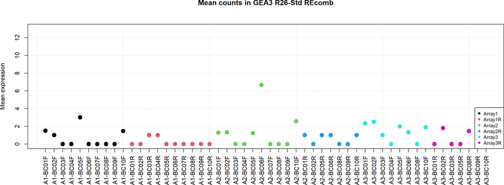

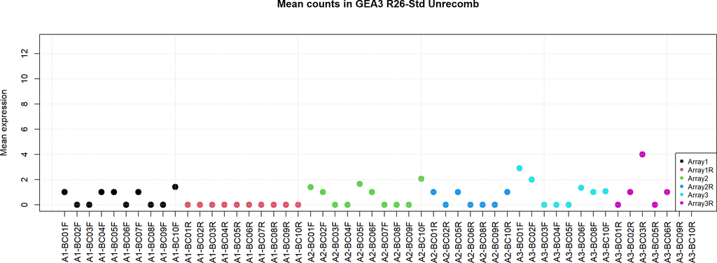

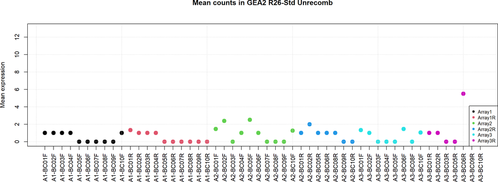

### 3.3.2 Looking at FRT-BC Counts

And Now instead of Mean counts per cell lets look at the total counts in the dataset

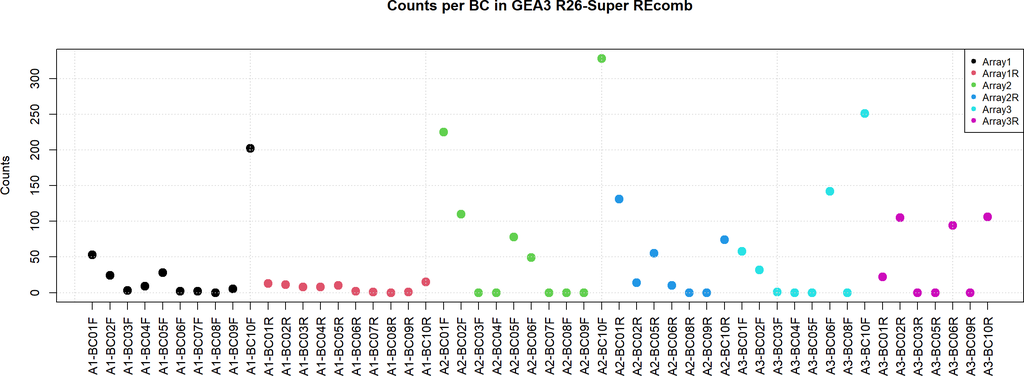

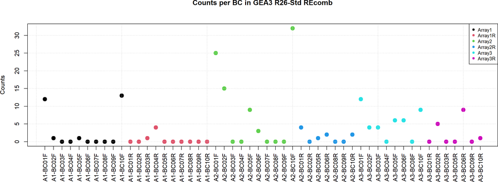

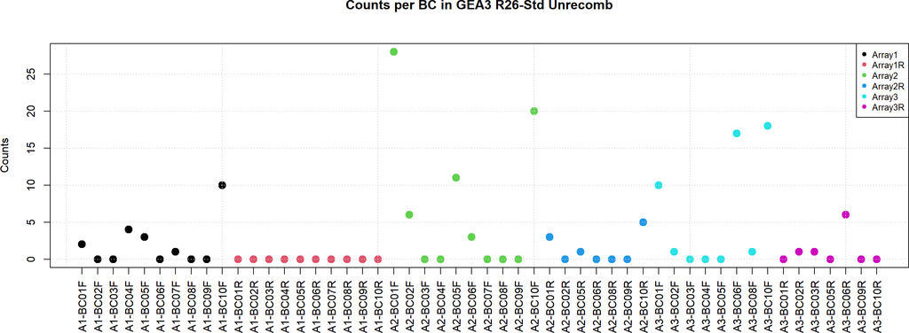

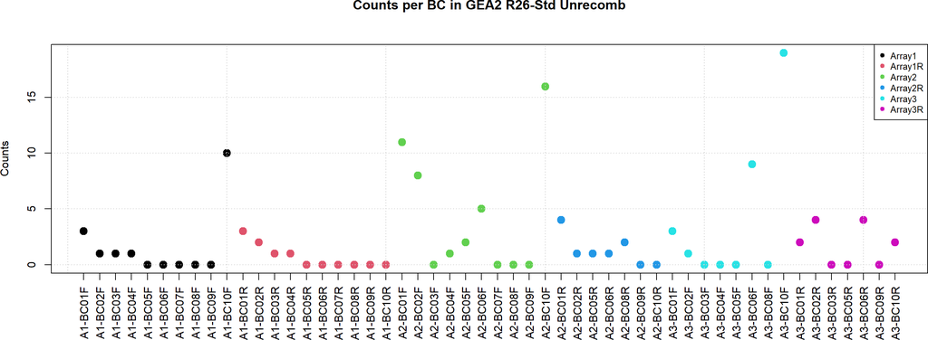

## 3.4 Doing a ratio analysis between Fwd and Inverted BC segment

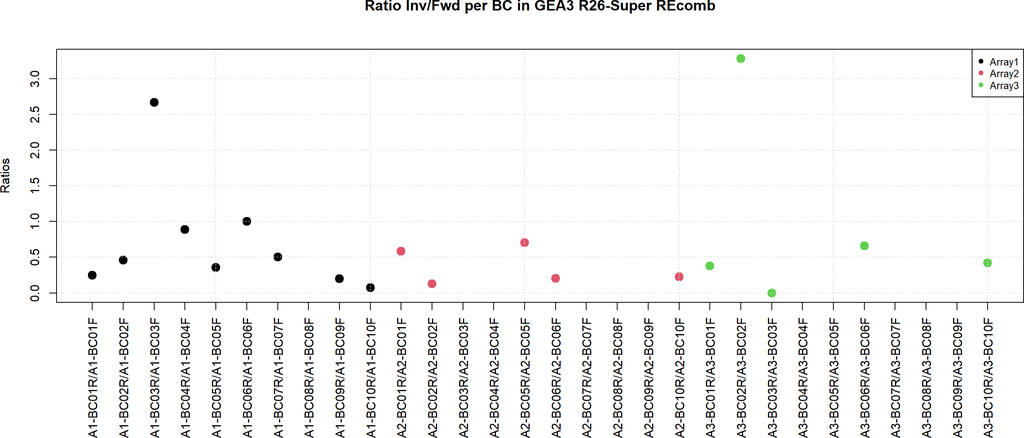

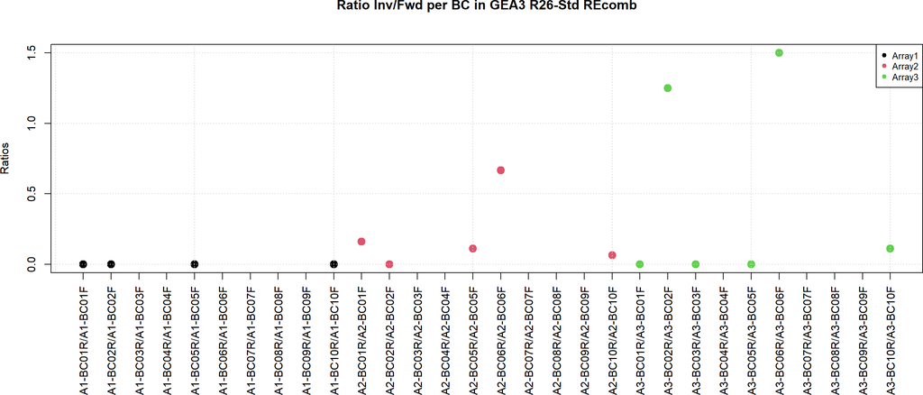

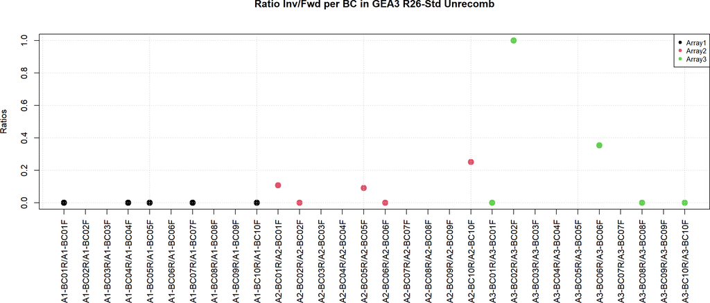

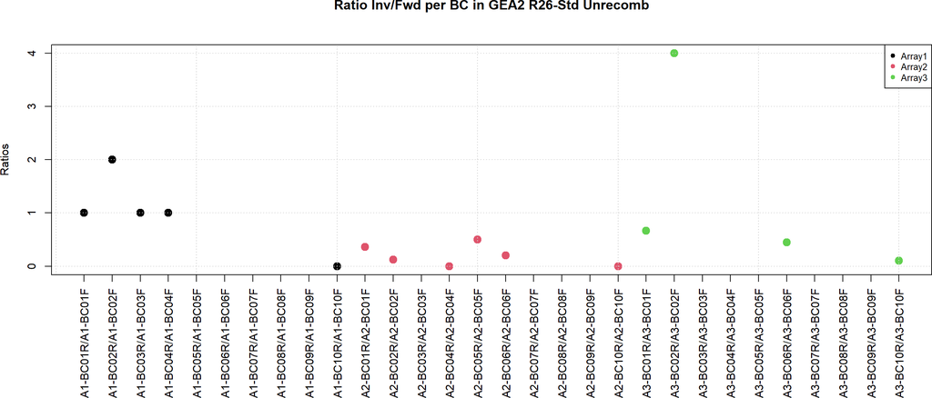

The ratio analysis between Inv/Fwd BC segments indicate a good level of Iverted BCs present in the dataset

## 3.5 Looking at the Distribution of other transgenes in the populations

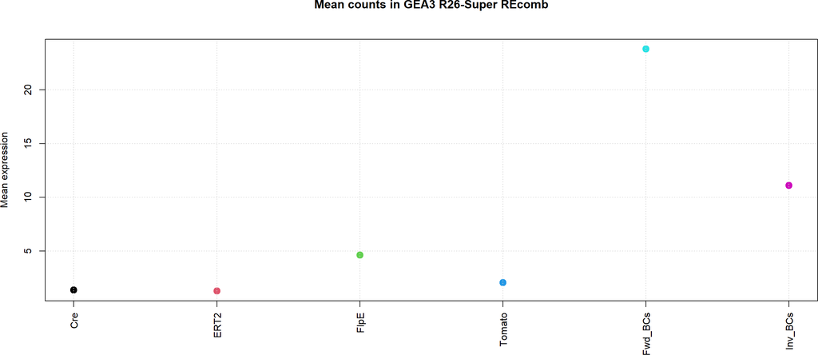

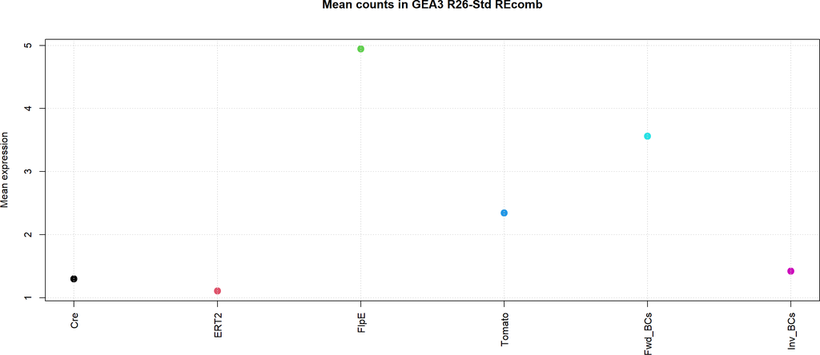

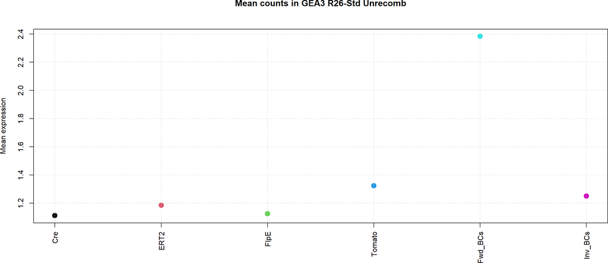

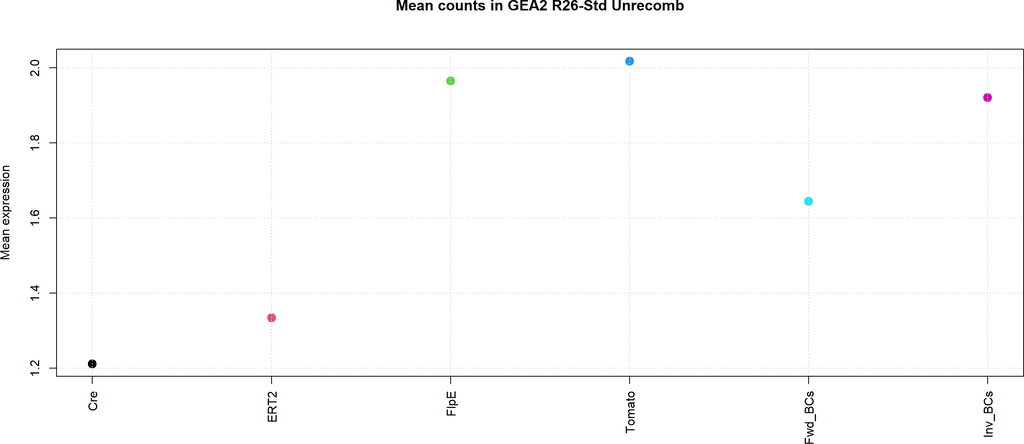

### 3.5.1 Looking at Transgene Counts

And Now instead of Mean counts per cell lets look at the total counts in the dataset

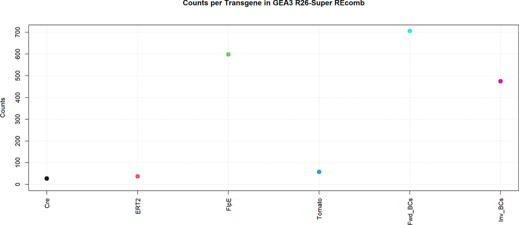

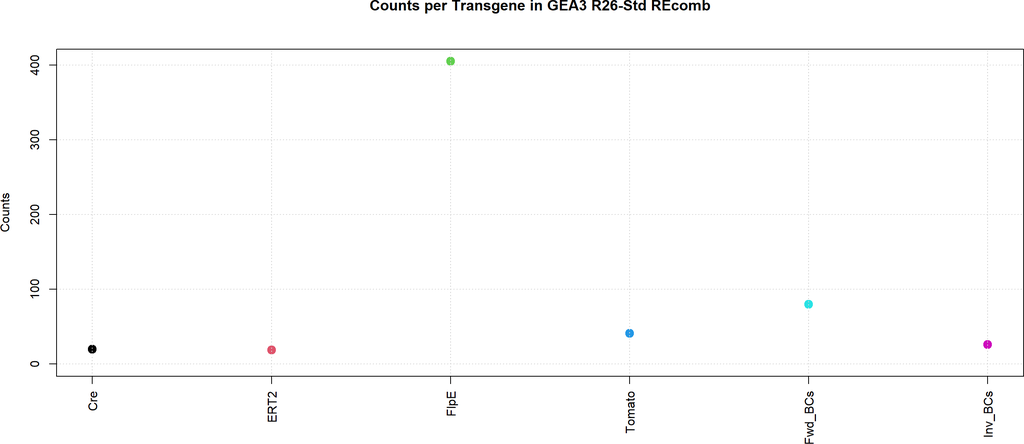

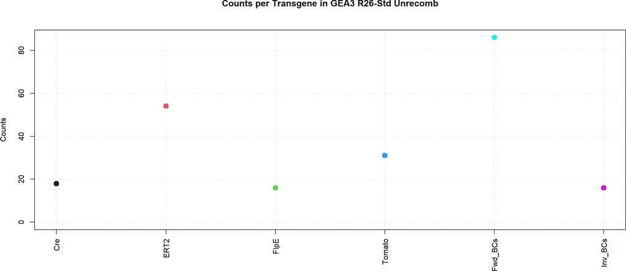

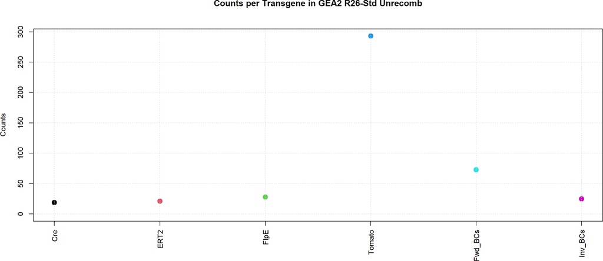

## 3.6 Looking at the other Transgenes present in the dataset

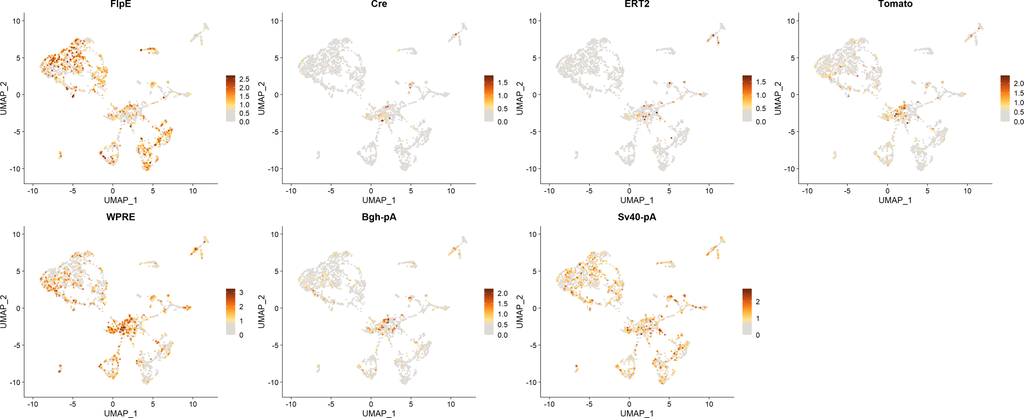

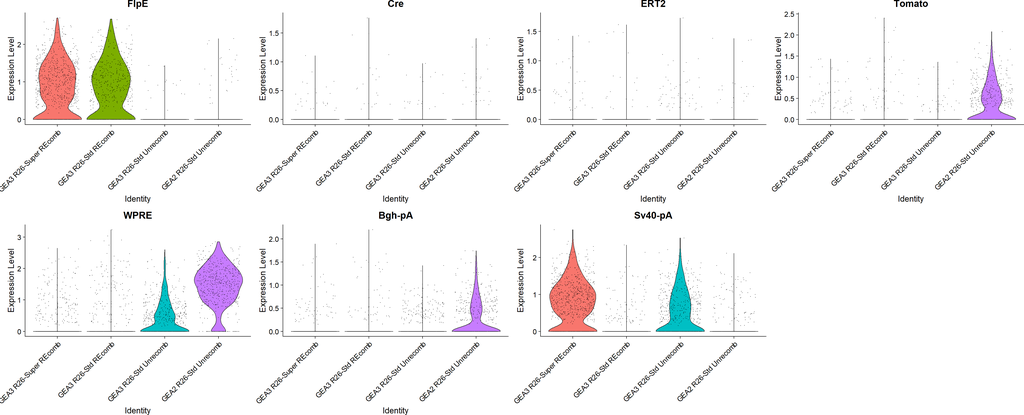

# 4 Conclusion

GEA12 undergoing full recombination is by far the best of all conditions present. Induction has worked by seeing the levels of expression of FlpE are only high in Fully recombined conditions There are issues in the correct alignment of Barcodes as in non recombined conditions appear levels of Reverse Barcodes. However, we can get rid of those issues by doing Nanopore sequencing, as Irepan’s RFR_ONT pipeline can correctly address that only properly oriented full transcript iFlpscLineage Barcodes pass the Analysis. Here I can only select for the most frequent Barcode in each cell, but I have not done it as it can bias the counts, favoring cells with degenerate BCs even more, and overall analysis.